# Cure model in Survival Analysis

Hwang Seong-Yun

2021 5 4

## Mixture cure model

### Loading packages

- Fit semiparametric PH(Proportional Hazard) mixture cure model or AFT(Accelerated Failure Time) mixture cure model by the EM algorithm

```r
library(smcure)
```

### Mixture cure model

- $S_{pop}(t|x,z)=[1-p(x)]+p(x)S_{u}(t|z)$
- $S_{pop}(t|x,z)=P(T>t|X=x,Z=z)$ : The survival function
- $p(x)=P(B=1|X=x)$ : The probability of being susceptible (often called the incidence of the model)
- $S_{u}(t|z)=P(T>t|Z=z,B=1)$ : The (proper) conditional survival function of the susceptibles (often called the latency of the model)
- $B=I(T<\infty)$ : The latent binary variable indicating whether someone is cured or not
- $F_{pop}(t|x,z)=p(x)F_{u}(t|z)$

### Fit PH(Proportional Hazard) mixture cure model

#### Eastern Cooperative Oncology Group (ECOG) data

- The melanoma data from the Eastern Cooperative Oncology Group (ECOG) phase III clinical trial e1684 which is used for modeling semicure PH mixture cure model (Kirkwood, et al., 1996)
- TRT : 0=control group, 1=IFN treatment group
- FAILTIME : observed relapse-free time
- FAILCENS : censoring indicator, 1=event of interest happens, and 0=censoring
- AGE : continuous variable, which is centered to the mean
- SEX : 0 for male, 1 for female

```r
data(e1684)
```

#### Fit logistic/Cox PH mixture cure model

- $p(x)=[exp(\gamma^{T}x)]/[1+exp(\gamma^{T}x)]$
- $S_{u}(t|z)=S_{0}(t)^{exp(\beta^{T}z)}$

```r
# fit logistic/Cox PH mixture cure model
pd <- smcure(Surv(FAILTIME,FAILCENS)~TRT+SEX+AGE,cureform=~TRT+SEX+AGE,data=e1684,model="ph",link="logit",Var=FALSE)
```

```
## Program is running..be patient... done.
## Call:
## smcure(formula = Surv(FAILTIME, FAILCENS) ~ TRT + SEX + AGE,
##     cureform = ~TRT + SEX + AGE, data = e1684, model = "ph",
##     link = "logit", Var = FALSE)
##
## Cure probability model:
##                Estimate
## (Intercept)  1.36493298
## TRT         -0.58847727
## SEX         -0.08696490
## AGE          0.02033857
##
##
## Failure time distribution model:
##         Estimate
## TRT -0.153595097
## SEX  0.099458470
## AGE -0.007664013
```

```r
pd
```

[output not shown]

[output cut: 88 more lines]

[output not shown]

```r
printsmcure(pd,Var=FALSE)
```

```
## Call:
## smcure(formula = Surv(FAILTIME, FAILCENS) ~ TRT + SEX + AGE,
##     cureform = ~TRT + SEX + AGE, data = e1684, model = "ph",
##     link = "logit", Var = FALSE)
##
## Cure probability model:
##                Estimate
## (Intercept)  1.36493298
## TRT         -0.58847727
## SEX         -0.08696490
## AGE          0.02033857
##
##
## Failure time distribution model:
##         Estimate
## TRT -0.153595097
## SEX  0.099458470
## AGE -0.007664013
```

- Predicted population survival function can be calculated by the following equation
- ${\hat{S}}_{pop}(t|x,z)=[1-{\hat{p}}(x)]+{\hat{p}}(x){\hat{S}}_{u}(t|z)$

```r
# plot predicted survival curves for male with median centered age by treatment groups
predm <- predictsmcure(pd,newX=cbind(c(1,0,1),c(0,0,1),c(0.475,0.613,0.826)),newZ=cbind(c(1,0,1),c(0,0,1),c(0.475,0.613,0.826)),model="ph")
predm
```

```
## $call
## predictsmcure(object = pd, newX = cbind(c(1, 0, 1), c(0, 0, 1),
##     c(0.475, 0.613, 0.826)), newZ = cbind(c(1, 0, 1), c(0, 0,
##     1), c(0.475, 0.613, 0.826)), model = "ph")
##
## $newuncureprob
##           [,1]      [,2]     [,3]
## [1,] 0.6869969 0.7985732 0.669581
##
## $prediction
##                                      Time
## 1   0.5729032 0.4588230 0.5599082 1.15068
## 2   0.6809550 0.5873199 0.6669986 0.62466
## 3   0.4876921 0.3634693 0.4785651 1.89863
## 4   0.7445148 0.6660191 0.7315817 0.45479
```

[output cut: 283 more lines]

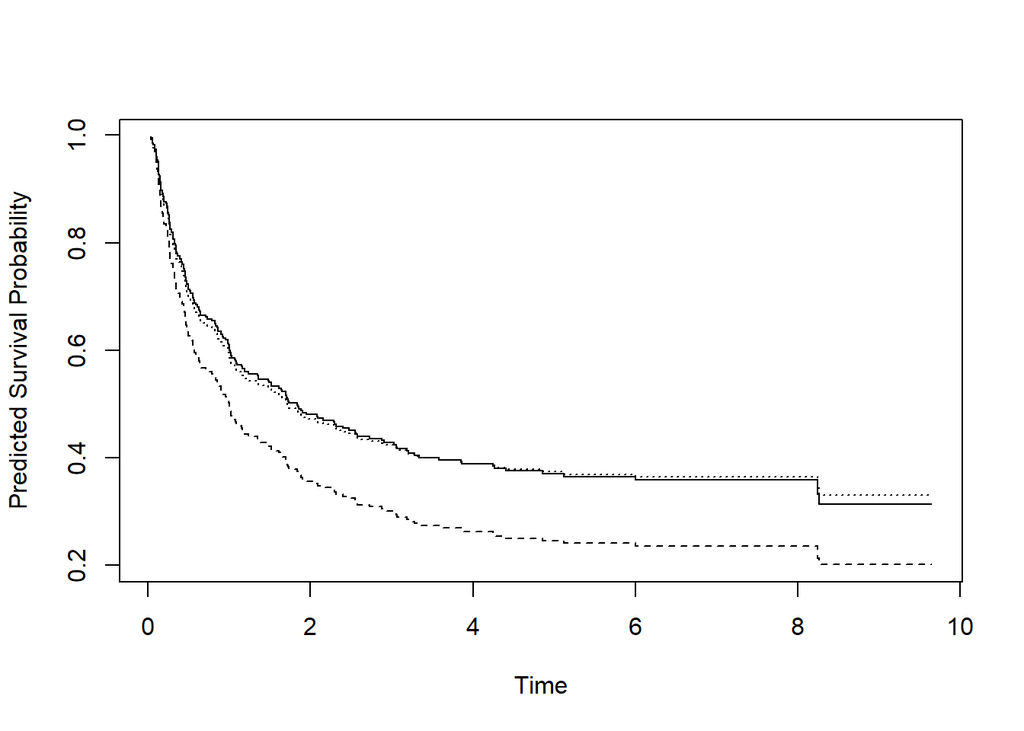

```r
plotpredictsmcure(predm,model="ph")
```

### Fit AFT(Accelerated Failure Time) mixture cure model

#### Bone marrow transplant study data

- Bone marrow transplant study for the refractory acute lymphoblastic leukemia patients which is widely used in the AFTMC model (Kersey, et al., 1987)
- Time : time to death
- Status : censoring indicator, 1=event of interest happens, and 0=censoring
- TRT : 1 for autologous treatment group; 0 for allogeneic treatment group

```r
data(bmt)
```

#### Fit logistic/semiparametric AFT models

- $log(T)=\beta^{T}Z+\epsilon$

```r
# fit AFT mixture cure model
bmtfit <- smcure(formula=Surv(Time,Status)~TRT,cureform=~TRT,data=bmt,model="aft",Var=FALSE)
```

```
## Program is running..be patient... done.
## Call:
## smcure(formula = Surv(Time, Status) ~ TRT, cureform = ~TRT, data = bmt,
##     model = "aft", Var = FALSE)
##
## Cure probability model:
##              Estimate
## (Intercept) 1.0073966
## TRT         0.4273086
##
##
## Failure time distribution model:
##               Estimate
## (Intercept)  0.2101563
## TRT         -0.3531250
```

```r
printsmcure(bmtfit,Var=FALSE)
```

```
## Call:
## smcure(formula = Surv(Time, Status) ~ TRT, cureform = ~TRT, data = bmt,
##     model = "aft", Var = FALSE)
##
## Cure probability model:
##              Estimate
## (Intercept) 1.0073966
## TRT         0.4273086
##
##
## Failure time distribution model:
##               Estimate
## (Intercept)  0.2101563
## TRT         -0.3531250
```

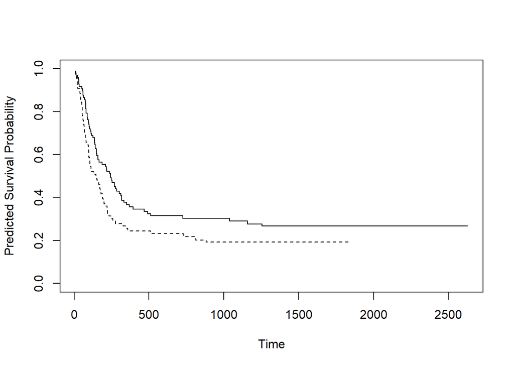

```r
# plot predicted Survival curves by treatment groups
predbmt=predictsmcure(bmtfit,newX=c(0,1),newZ=c(0,1),model="aft")
plotpredictsmcure(predbmt,model="aft")
```

## Promotion time cure model

### Loading packages

- Fits Semiparametric Promotion Time Cure Models, taking into account (using a corrected score approach or the SIMEX algorithm) or not the measurement error in the covariates, using a backfitting approach to maximize the likelihood.

```r
library(miCoPTCM)
```

### Promotion time cure model

- $S_{pop}(t|x)=exp[-\theta(x)F(t)]$
- $S_{pop}(t|x)=P(T>t|X=x)$ : The survival function
- $F(t)$ : A proper baseline distribution function
- $\theta(x)$ : Captures the effect of the covariates $x$ on the survival function $S_{pop}(t|x)$
- $P(B=0|X=x)=exp[-\theta(x)]$ : The cure proportion
- $W=X+U$ : The classical additive measurement error model ($W$ : The vector of observed covariates, $U$ : The vector of measurement errors($U \sim N_{p}(0,V)$, where $V$ is known, and $U$ is independent of $X$, $(T,C)$ and $W$ are independent given $X$))

### Corrected score approach

- Fits a Semiparametric Promotion Time Cure Model, taking into account (using a corrected score approach) or not the measurement error in the covariates, using a backfitting approach to maximize the likelihood. Both methods were introduced in Ma and Yin (2008).

```r
library("survival")
## Data generation
set.seed(123)
n <- 200
varCov <- matrix(nrow=3,ncol=3,0)
varCov[2,2] <- 0.1^1
X1 <- (runif(n)-0.5)/sqrt(1/12)
V <- round(X1+rnorm(n,rep(0,3),varCov[2,2]),7)# covariate with measurement error
Xc <- round(as.numeric(runif(n)<0.5),7) # covariate without measurement error

 # censoring times: truncated exponential distribution
C <- round(rexp(n,1/5),5)
Cbin <- (C>30)
while (sum(Cbin)>0) {
    C[Cbin] <- round(rexp(sum(Cbin),1/5),5)
    Cbin <- (C>30) }

expb <- exp(0.5+X1-0.5*Xc)
cure <- exp(-expb) # cure probabilities

 # event times with baseline cdf of a truncated exponential
U <- runif(n)
d <- rep(NA,n)
T <- round(-6*log(1+(1-exp(-20/6))*log(1-(1-cure)*U)/expb),5)
T[(runif(n)<cure)] <- 99999 # cured subjects

Tobs <- rep(NA,n)
Tobs <- pmin(C,T) # observed times
Tmax <- max(Tobs[Tobs==T])
d <- (Tobs==T) # censoring indicator

Dat <- data.frame(Tobs,d,V,Xc)
#colnames(Dat) <- c("Tobs","d","V","Xc")

## Model estimation
fm <- formula(Surv(Tobs,d)~V+Xc)
resMY <- PTCMestimBF(fm,Dat,varCov=varCov,init=rnorm(3))
resMY
```

```
## Call:
## PTCMestimBF.formula(formula = fm, data = Dat, varCov = varCov,
##     init = rnorm(3))
##
## Coefficients:
## [1]  0.4926483  1.0915978 -0.8000807
```

```r
summary(resMY)
```

```
## Call:
## PTCMestimBF.formula(formula = fm, data = Dat, varCov = varCov,
##     init = rnorm(3))
##
##           Estimate   StdErr z.value   p.value
## Intercept  0.49265  0.20525  2.4002 0.0163843 *
## V          1.09160  0.15745  6.9330 4.121e-12 ***
## Xc        -0.80008  0.23258 -3.4400 0.0005817 ***
## ---
## Signif. codes:  0 '***' 0.001 '**' 0.01 '*' 0.05 '.' 0.1 ' ' 1
```

### SIMEX approach

- Fits a Semiparametric Promotion Time Cure Model with mismeasured covariates, using the SIMEX algorithm based on a backfitting procedure. This approach is introduced in Bertrand et al. (2015).

```r
## Not run:
library("survival")
## Data generation
set.seed(123)
n <- 200
varCov <- matrix(nrow=3,ncol=3,0)
varCov[2,2] <- 0.1^1
X1 <- (runif(n)-0.5)/sqrt(1/12)
V <- round(X1+rnorm(n,rep(0,3),varCov[2,2]),7)# covariate with measurement error
Xc <- round(as.numeric(runif(n)<0.5),7) # covariate without measurement error

 # censoring times: truncated exponential distribution
C <- round(rexp(n,1/5),5)
Cbin <- (C>30)
while (sum(Cbin)>0) {
    C[Cbin] <- round(rexp(sum(Cbin),1/5),5)
    Cbin <- (C>30) }

expb <- exp(0.5+X1-0.5*Xc)
cure <- exp(-expb) # cure probabilities

 # event times with baseline cdf of a truncated exponential
U <- runif(n)
d <- rep(NA,n)
T <- round(-6*log(1+(1-exp(-20/6))*log(1-(1-cure)*U)/expb),5)
T[(runif(n)<cure)] <- 99999 # cured subjects

Tobs <- rep(NA,n)
Tobs <- pmin(C,T) # observed times
Tmax <- max(Tobs[Tobs==T])
d <- (Tobs==T) # censoring indicator

Dat <- data.frame(Tobs,d,V,Xc)

## Model estimation
fm <- formula(Surv(Tobs,d)~V+Xc)
resSimex <- PTCMestimSIMEX(fm,Dat,errorDistEstim="normal",
varCov=varCov,nBack=10000,eps=1e-8,Nu=c(0,0.5,1,1.5,2),B=50,init=rnorm(3),orderExtrap=1:3,multMaxTime=2)
```

```
## [1] "Level of added noise :  0"
```

```
## [1] "Level of added noise :  0.5"
```

[output not shown]

[output cut: 94 more lines]

[output not shown]

```
## [1] "Level of added noise :  1"
```

[output not shown]

[output cut: 94 more lines]

[output not shown]

```
## [1] "Level of added noise :  1.5"
```

[output not shown]

[output cut: 94 more lines]

[output not shown]

```
## [1] "Level of added noise :  2"
```

[output not shown]

[output cut: 94 more lines]

[output not shown]

```r
resSimex
```

```
## Call:
## PTCMestimSIMEX.formula(formula = fm, data = Dat, errorDistEstim = "normal",
##     varCov = varCov, nBack = 10000, eps = 1e-08, Nu = c(0, 0.5,
##         1, 1.5, 2), B = 50, init = rnorm(3), orderExtrap = 1:3,
##     multMaxTime = 2)
##
## Coefficients with extrapolant of order  1 :
##  Intercept          V         Xc
##  0.4717311  1.0186132 -0.7797378
##
## Coefficients with extrapolant of order  2 :
##  Intercept          V         Xc
##  0.4728921  1.0667096 -0.7736549
##
## Coefficients with extrapolant of order  3 :
##  Intercept          V         Xc
##  0.4638895  1.0882993 -0.7562137
```

```r
summary(resSimex)
```

```
## Call:
## PTCMestimSIMEX.formula(formula = fm, data = Dat, errorDistEstim = "normal",
##     varCov = varCov, nBack = 10000, eps = 1e-08, Nu = c(0, 0.5,
##         1, 1.5, 2), B = 50, init = rnorm(3), orderExtrap = 1:3,
##     multMaxTime = 2)
##
## Results with extrapolant of order  1 :
##           Estimate   StdErr z.value   p.value
## Intercept  0.47173  0.20142  2.3420 0.0191802 *
## V          1.01861  0.12559  8.1103 5.048e-16 ***
## Xc        -0.77974  0.22687 -3.4370 0.0005882 ***
## ---
## Signif. codes:  0 '***' 0.001 '**' 0.01 '*' 0.05 '.' 0.1 ' ' 1
##
## Results with extrapolant of order  2 :
##           Estimate   StdErr z.value   p.value
## Intercept  0.47289  0.21300  2.2201 0.0264089 *
## V          1.06671  0.13883  7.6836 1.547e-14 ***
## Xc        -0.77365  0.23404 -3.3057 0.0009474 ***
## ---
## Signif. codes:  0 '***' 0.001 '**' 0.01 '*' 0.05 '.' 0.1 ' ' 1
##
## Results with extrapolant of order  3 :
##           Estimate   StdErr z.value   p.value
## Intercept  0.46389  0.21786  2.1293  0.033233 *
## V          1.08830  0.14596  7.4561 8.909e-14 ***
## Xc        -0.75621  0.23642 -3.1986  0.001381 **
## ---
## Signif. codes:  0 '***' 0.001 '**' 0.01 '*' 0.05 '.' 0.1 ' ' 1
```

```r
## End(Not run)
```